# Module 22

#### Contrast SVE:

Signed variance explained (SVE) provides an indication of how similar a set of fold changes are to a gene module’s weight vector. An SVE value of 0.3, for example, indicates that 30% of the variance explained by the entire module set is accounted for by the module in question. Shown here are the SVE values for this module across a compendium of fold changes (contrasts). Extreme SVE values (e.g., > 0.05) indicate that those contrasts specifically induce (orange dots) or specifically repress (blue dots) this module. Examining the experimental conditions being compared in such contrasts (see tables below the figure) may provide insight into the gene module’s function.

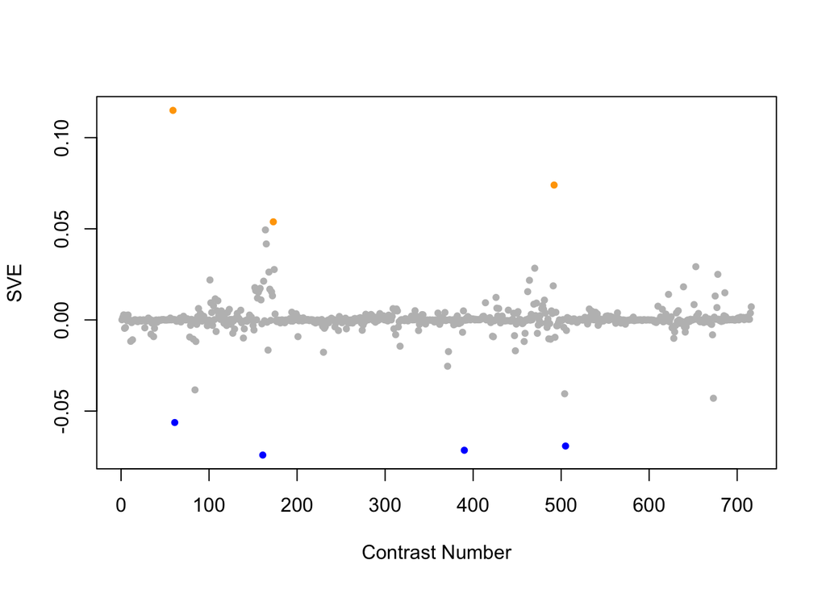

Positive SVE Contrasts:

|  | Contrast.Num | SVE | GEO.GSE | Cond.1 | Cond.2 | Mutation |
| --- | --- | --- | --- | --- | --- | --- |
| GSE9301.s2t1.vs.s1t1 | 59 | 0.11 | GSE9301 | 3-day-old TJ1090 worms with skn-1 RNAi & oxidative stress (SO1) | 3-day-old TJ1090 worms with oxidative stress (O1) | skn-1 |
| GSE23528B.s1t6.vs.s1t1 | 492 | 0.07 | GSE23528 | Adult at T46 in CC, time-series experiment 3 | Adult at T26 in CC, time-series experiment 3 |  |
| GSE47778.s1t3.vs.s4t3 | 173 | 0.05 | GSE47778 | N2; UV; replicate 1 | daf-2;daf-16; UV; replicate 1 | daf-2;daf-16 |
| GSE47778.s1t2.vs.s2t2 | 164 | 0.05 | GSE47778 | N2; starvation; replicate 1 | daf-2; starvation; replicate 1 | daf-2 |
| GSE47778.s1t2.vs.s4t2 | 165 | 0.04 | GSE47778 | N2; starvation; replicate 1 | daf-2;daf-16; starvation; replicate 1 | daf-2;daf-16 |

Negative SVE Contrasts:

|  | Contrast.Num | SVE | GEO.GSE | Cond.1 | Cond.2 | Mutation |
| --- | --- | --- | --- | --- | --- | --- |
| GSE47778.s4t2.vs.s3t2 | 161 | -0.07 | GSE47778 | daf-2;daf-16; starvation; replicate 1 | daf-16; starvation; replicate 1 | daf-2;daf-16 vs. daf-16 |
| GSE32521.s1t1.vs.s0t1 | 390 | -0.07 | GSE32521 | Au-NP Replicate1 | Control Replicate1 |  |
| GSE22660.s1t2.vs.s1t1 | 505 | -0.07 | GSE22660 | 1ug/ml ivermectin exposure, biological rep 1 | 100ng/ml ivermectin exposure, biological rep 1 |  |
| GSE9301.s3t1.vs.s2t1 | 61 | -0.06 | GSE9301 | 3-day-old TJ1090 worms without any stress (C1) | 3-day-old TJ1090 worms with skn-1 RNAi & oxidative stress (SO1) |  |
| GSE14640B.s1t1.vs.s0t1 | 673 | -0.04 | GSE14640 | XX_DPY27-N_042807_A | XX_WT-N_080307_A |  |

$~$

#### Contrast SVE, Up-Regulated Genes Only:

Calculating SVE for up-regulated and down-regulated genes separately may be more informative in many cases than projecting the up- and down- gene sets together. This is due to the fact that the weight distribution of many modules is highly skewed, indicating that only one of the hemi-modules may be biologically meaningful (i.e., a set of genes are strongly correlated by only a few genes (or none) are strongly anti-correlated to that set.)

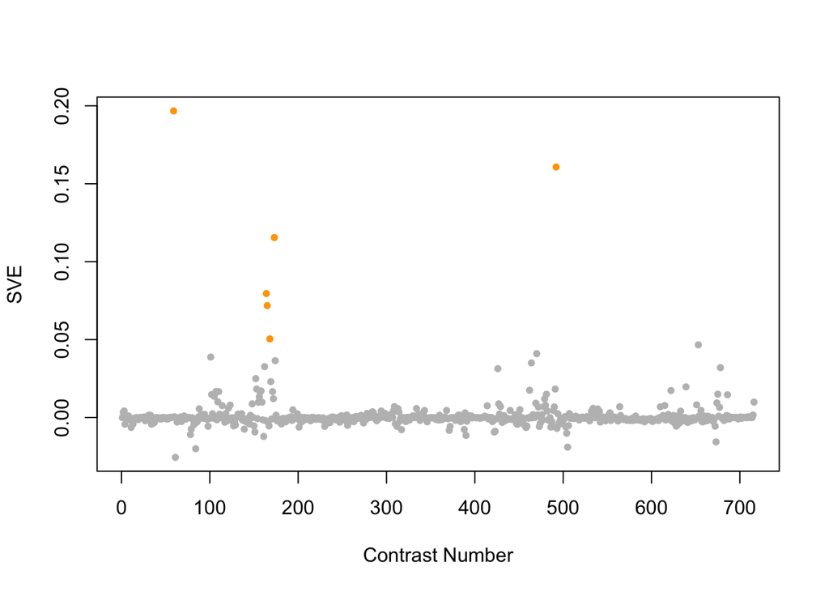

Positive SVE Contrasts:

|  | Contrast.Num | SVE | GEO.GSE | Cond.1 | Cond.2 | Mutation |
| --- | --- | --- | --- | --- | --- | --- |
| GSE9301.s2t1.vs.s1t1 | 59 | 0.20 | GSE9301 | 3-day-old TJ1090 worms with skn-1 RNAi & oxidative stress (SO1) | 3-day-old TJ1090 worms with oxidative stress (O1) | skn-1 |
| GSE23528B.s1t6.vs.s1t1 | 492 | 0.16 | GSE23528 | Adult at T46 in CC, time-series experiment 3 | Adult at T26 in CC, time-series experiment 3 |  |
| GSE47778.s1t3.vs.s4t3 | 173 | 0.12 | GSE47778 | N2; UV; replicate 1 | daf-2;daf-16; UV; replicate 1 | daf-2;daf-16 |
| GSE47778.s1t2.vs.s2t2 | 164 | 0.08 | GSE47778 | N2; starvation; replicate 1 | daf-2; starvation; replicate 1 | daf-2 |
| GSE47778.s1t2.vs.s4t2 | 165 | 0.07 | GSE47778 | N2; starvation; replicate 1 | daf-2;daf-16; starvation; replicate 1 | daf-2;daf-16 |
| GSE47778.s1t3.vs.s3t3 | 168 | 0.05 | GSE47778 | N2; UV; replicate 1 | daf-16; UV; replicate 1 | daf-16 |

Negative SVE Contrasts:

|  | Contrast.Num | SVE | GEO.GSE | Cond.1 | Cond.2 | Mutation |
| --- | --- | --- | --- | --- | --- | --- |
| GSE9301.s3t1.vs.s2t1 | 61 | -0.03 | GSE9301 | 3-day-old TJ1090 worms without any stress (C1) | 3-day-old TJ1090 worms with skn-1 RNAi & oxidative stress (SO1) |  |
| GSE6547.s2t2.vs.s0t2 | 84 | -0.02 | GSE6547 | slr-2(ku297) worms at L1 stage, first replicate | N2 (wt) worms at L1 stage, first replicate | sir-2 |
| GSE22660.s1t2.vs.s1t1 | 505 | -0.02 | GSE22660 | 1ug/ml ivermectin exposure, biological rep 1 | 100ng/ml ivermectin exposure, biological rep 1 |  |
| GSE14640B.s1t1.vs.s0t1 | 673 | -0.02 | GSE14640 | XX_DPY27-N_042807_A | XX_WT-N_080307_A |  |
| GSE47778.s4t2.vs.s3t2 | 161 | -0.01 | GSE47778 | daf-2;daf-16; starvation; replicate 1 | daf-16; starvation; replicate 1 | daf-2;daf-16 vs. daf-16 |

$~$

#### Contrast SVE, Down-Regulated Genes Only:

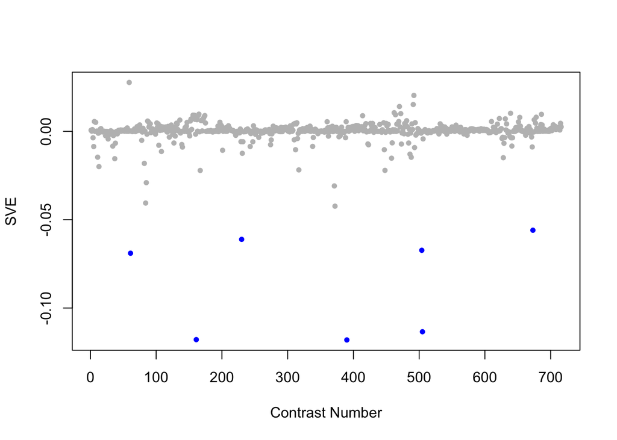

Positive SVE Contrasts:

|  | Contrast.Num | SVE | GEO.GSE | Cond.1 | Cond.2 | Mutation |
| --- | --- | --- | --- | --- | --- | --- |
| GSE9301.s2t1.vs.s1t1 | 59 | 0.03 | GSE9301 | 3-day-old TJ1090 worms with skn-1 RNAi & oxidative stress (SO1) | 3-day-old TJ1090 worms with oxidative stress (O1) | skn-1 |
| GSE23528B.s1t6.vs.s1t1 | 492 | 0.02 | GSE23528 | Adult at T46 in CC, time-series experiment 3 | Adult at T26 in CC, time-series experiment 3 |  |
| GSE23528B.s1t5.vs.s1t1 | 491 | 0.02 | GSE23528 | Adult at T42 in CC, time-series experiment 3 | Adult at T26 in CC, time-series experiment 3 |  |
| GSE23528A.s2t6.vs.s0t6 | 470 | 0.01 | GSE23528 | Adult at T22 in WC, time-series experiment 1 | Adult at T22, non-entrained control time-series experiment 4 |  |
| GSE23528A.s2t3.vs.s0t3 | 462 | 0.01 | GSE23528 | Adult at T10 in WC, time-series experiment 1 | Adult at T10, non-entrained control time-series experiment 4 |  |

Negative SVE Contrasts:

|  | Contrast.Num | SVE | GEO.GSE | Cond.1 | Cond.2 | Mutation |
| --- | --- | --- | --- | --- | --- | --- |
| GSE32521.s1t1.vs.s0t1 | 390 | -0.12 | GSE32521 | Au-NP Replicate1 | Control Replicate1 |  |
| GSE47778.s4t2.vs.s3t2 | 161 | -0.12 | GSE47778 | daf-2;daf-16; starvation; replicate 1 | daf-16; starvation; replicate 1 | daf-2;daf-16 vs. daf-16 |
| GSE22660.s1t2.vs.s1t1 | 505 | -0.11 | GSE22660 | 1ug/ml ivermectin exposure, biological rep 1 | 100ng/ml ivermectin exposure, biological rep 1 |  |
| GSE9301.s3t1.vs.s2t1 | 61 | -0.07 | GSE9301 | 3-day-old TJ1090 worms without any stress (C1) | 3-day-old TJ1090 worms with skn-1 RNAi & oxidative stress (SO1) |  |
| GSE22660.s0t2.vs.s0t1 | 504 | -0.07 | GSE22660 | 1ug/ml DMSO control, biological rep 1 | 100ng/ml DMSO control, biological rep 1 |  |
| GSE42592B.s1t3.vs.s0t3 | 230 | -0.06 | GSE42592 | cadmium_low_expose-8h_rep1 | cadmium_control_expose-8h_rep1 |  |
| GSE14640B.s1t1.vs.s0t1 | 673 | -0.06 | GSE14640 | XX_DPY27-N_042807_A | XX_WT-N_080307_A |  |

$~$

$~$

#### GO Term Enrichment:

This analysis tests each hemi-module for enrichment of specific GO terms. Only gene-level annotations (e.g., as would be found on the gene’s page in Wormbase) are tested - the hierarchical structure of the GO ontology is not taken into account.

*Note: At least the top two most enriched terms from each GO domain (BP/MF/CC) are shown, even when not statistically significant.*

##### Enriched GO terms: Hemi-module A

| ID | GO.Term | GO Domain | Raw p-value | Adj p-value |
| --- | --- | --- | --- | --- |
| [GO_0009792](http://amigo.geneontology.org/amigo/term/GO:0009792) | embryo development ending in birth or egg hatching | BP | 1.03e-15 | 3.75e-12 |
| [GO_0006897](http://amigo.geneontology.org/amigo/term/GO:0006897) | endocytosis | BP | 3.90e-08 | 7.11e-05 |
| [GO_0000147](http://amigo.geneontology.org/amigo/term/GO:0000147) | actin cortical patch assembly | BP | 9.92e-08 | 7.23e-05 |
| [GO_0030048](http://amigo.geneontology.org/amigo/term/GO:0030048) | actin filament-based movement | BP | 9.92e-08 | 7.23e-05 |
| [GO_0051666](http://amigo.geneontology.org/amigo/term/GO:0051666) | actin cortical patch localization | BP | 9.92e-08 | 7.23e-05 |
| [GO_0010940](http://amigo.geneontology.org/amigo/term/GO:0010940) | positive regulation of necrotic cell death | BP | 7.36e-07 | 4.47e-04 |
| [GO_0006898](http://amigo.geneontology.org/amigo/term/GO:0006898) | receptor-mediated endocytosis | BP | 3.05e-06 | 1.59e-03 |
| [GO_0002119](http://amigo.geneontology.org/amigo/term/GO:0002119) | nematode larval development | BP | 4.50e-06 | 2.05e-03 |
| [GO_0007275](http://amigo.geneontology.org/amigo/term/GO:0007275) | multicellular organism development | BP | 1.83e-05 | 7.40e-03 |
| [GO_0006886](http://amigo.geneontology.org/amigo/term/GO:0006886) | intracellular protein transport | BP | 1.04e-04 | 3.79e-02 |
| [GO_0008361](http://amigo.geneontology.org/amigo/term/GO:0008361) | regulation of cell size | BP | 1.87e-04 | 5.51e-02 |
| [GO_0051661](http://amigo.geneontology.org/amigo/term/GO:0051661) | maintenance of centrosome location | BP | 1.87e-04 | 5.51e-02 |
| [GO_0009306](http://amigo.geneontology.org/amigo/term/GO:0009306) | protein secretion | BP | 1.97e-04 | 5.51e-02 |
| [GO_0031114](http://amigo.geneontology.org/amigo/term/GO:0031114) | regulation of microtubule depolymerization | BP | 3.18e-04 | 7.24e-02 |
| [GO_0090306](http://amigo.geneontology.org/amigo/term/GO:0090306) | spindle assembly involved in meiosis | BP | 3.18e-04 | 7.24e-02 |
| [GO_1905833](http://amigo.geneontology.org/amigo/term/GO:1905833) | negative regulation of microtubule nucleation | BP | 3.18e-04 | 7.24e-02 |
| [GO_0045167](http://amigo.geneontology.org/amigo/term/GO:0045167) | asymmetric protein localization involved in cell fate determination | BP | 3.84e-04 | 8.22e-02 |
| [GO_0043277](http://amigo.geneontology.org/amigo/term/GO:0043277) | apoptotic cell clearance | BP | 4.37e-04 | 8.83e-02 |
| [GO_0005515](http://amigo.geneontology.org/amigo/term/GO:0005515) | protein binding | MF | 2.68e-18 | 5.47e-15 |
| [GO_0000166](http://amigo.geneontology.org/amigo/term/GO:0000166) | nucleotide binding | MF | 2.44e-06 | 2.07e-03 |
| [GO_0003676](http://amigo.geneontology.org/amigo/term/GO:0003676) | nucleic acid binding | MF | 3.19e-06 | 2.07e-03 |
| [GO_0008017](http://amigo.geneontology.org/amigo/term/GO:0008017) | microtubule binding | MF | 4.05e-06 | 2.07e-03 |
| [GO_0004674](http://amigo.geneontology.org/amigo/term/GO:0004674) | protein serine/threonine kinase activity | MF | 3.00e-05 | 1.23e-02 |
| [GO_0051015](http://amigo.geneontology.org/amigo/term/GO:0051015) | actin filament binding | MF | 1.38e-04 | 4.70e-02 |
| [GO_0003924](http://amigo.geneontology.org/amigo/term/GO:0003924) | GTPase activity | MF | 2.05e-04 | 5.97e-02 |
| [GO_0005524](http://amigo.geneontology.org/amigo/term/GO:0005524) | ATP binding | MF | 2.76e-04 | 7.05e-02 |
| [GO_0005519](http://amigo.geneontology.org/amigo/term/GO:0005519) | cytoskeletal regulatory protein binding | MF | 3.18e-04 | 7.22e-02 |
| [GO_0005737](http://amigo.geneontology.org/amigo/term/GO:0005737) | cytoplasm | CC | 1.09e-13 | 1.01e-10 |
| [GO_0016021](http://amigo.geneontology.org/amigo/term/GO:0016021) | integral component of membrane | CC | 3.19e-12 | 1.48e-09 |
| [GO_0016020](http://amigo.geneontology.org/amigo/term/GO:0016020) | membrane | CC | 5.86e-08 | 1.81e-05 |
| [GO_0005884](http://amigo.geneontology.org/amigo/term/GO:0005884) | actin filament | CC | 1.24e-06 | 2.76e-04 |
| [GO_0005938](http://amigo.geneontology.org/amigo/term/GO:0005938) | cell cortex | CC | 1.49e-06 | 2.76e-04 |
| [GO_0005634](http://amigo.geneontology.org/amigo/term/GO:0005634) | nucleus | CC | 2.09e-06 | 3.24e-04 |
| [GO_0005875](http://amigo.geneontology.org/amigo/term/GO:0005875) | microtubule associated complex | CC | 5.63e-06 | 7.46e-04 |
| [GO_0030479](http://amigo.geneontology.org/amigo/term/GO:0030479) | actin cortical patch | CC | 1.16e-05 | 1.35e-03 |
| [GO_0030117](http://amigo.geneontology.org/amigo/term/GO:0030117) | membrane coat | CC | 1.91e-05 | 1.97e-03 |
| [GO_0005813](http://amigo.geneontology.org/amigo/term/GO:0005813) | centrosome | CC | 3.69e-05 | 3.43e-03 |
| [GO_0005874](http://amigo.geneontology.org/amigo/term/GO:0005874) | microtubule | CC | 8.01e-05 | 6.67e-03 |
| [GO_0055038](http://amigo.geneontology.org/amigo/term/GO:0055038) | recycling endosome membrane | CC | 8.62e-05 | 6.67e-03 |
| [GO_0016442](http://amigo.geneontology.org/amigo/term/GO:0016442) | RISC complex | CC | 1.08e-04 | 7.72e-03 |
| [GO_0005794](http://amigo.geneontology.org/amigo/term/GO:0005794) | Golgi apparatus | CC | 1.28e-04 | 8.51e-03 |
| [GO_0070971](http://amigo.geneontology.org/amigo/term/GO:0070971) | endoplasmic reticulum exit site | CC | 1.87e-04 | 1.16e-02 |
| [GO_0000139](http://amigo.geneontology.org/amigo/term/GO:0000139) | Golgi membrane | CC | 3.55e-04 | 2.06e-02 |
| [GO_0005802](http://amigo.geneontology.org/amigo/term/GO:0005802) | trans-Golgi network | CC | 5.63e-04 | 3.07e-02 |
| [GO_1904115](http://amigo.geneontology.org/amigo/term/GO:1904115) | axon cytoplasm | CC | 6.15e-04 | 3.17e-02 |
| [GO_1990904](http://amigo.geneontology.org/amigo/term/GO:1990904) | ribonucleoprotein complex | CC | 6.88e-04 | 3.36e-02 |
| [GO_0005834](http://amigo.geneontology.org/amigo/term/GO:0005834) | heterotrimeric G-protein complex | CC | 9.34e-04 | 4.16e-02 |
| [GO_0005952](http://amigo.geneontology.org/amigo/term/GO:0005952) | cAMP-dependent protein kinase complex | CC | 9.42e-04 | 4.16e-02 |
| [GO_0030056](http://amigo.geneontology.org/amigo/term/GO:0030056) | hemidesmosome | CC | 1.41e-03 | 5.95e-02 |
| [GO_0005818](http://amigo.geneontology.org/amigo/term/GO:0005818) | aster | CC | 1.86e-03 | 7.20e-02 |
| [GO_0030121](http://amigo.geneontology.org/amigo/term/GO:0030121) | AP-1 adaptor complex | CC | 1.86e-03 | 7.20e-02 |
| [GO_0005856](http://amigo.geneontology.org/amigo/term/GO:0005856) | cytoskeleton | CC | 2.15e-03 | 8.00e-02 |

##### Enriched GO terms: Hemi-module B

| ID | GO.Term | GO Domain | Raw p-value | Adj p-value |
| --- | --- | --- | --- | --- |
| [GO_0045786](http://amigo.geneontology.org/amigo/term/GO:0045786) | negative regulation of cell cycle | BP | 9.97e-04 | 1.00e+00 |
| [GO_0048213](http://amigo.geneontology.org/amigo/term/GO:0048213) | Golgi vesicle prefusion complex stabilization | BP | 9.97e-04 | 1.00e+00 |
| [GO_0052856](http://amigo.geneontology.org/amigo/term/GO:0052856) | NADHX epimerase activity | MF | 1.99e-03 | 1.00e+00 |
| [GO_0052857](http://amigo.geneontology.org/amigo/term/GO:0052857) | NADPHX epimerase activity | MF | 1.99e-03 | 1.00e+00 |
| [GO_0005815](http://amigo.geneontology.org/amigo/term/GO:0005815) | microtubule organizing center | CC | 7.68e-04 | 3.73e-01 |
| [GO_1902636](http://amigo.geneontology.org/amigo/term/GO:1902636) | kinociliary basal body | CC | 9.97e-04 | 3.73e-01 |

$~$

$~$

#### Tissue Enrichment:

This analysis tests each hemi-module for enrichment of genes associated with anatomy terms. Negative enrichment scores indicate fewer hemi-module genes than expected by random chance were associated with the anatomy term in question.

##### Enriched tissues: Hemi-module A

| ID | Anatomy.Term | Definition | Raw p-value | Adj p-value |
| --- | --- | --- | --- | --- |
| [WBbt_0006749](https://wormbase.org/species/all/anatomy_term/WBbt:0006749) | nerve ring | the most extensive region of neuropil in the animal, consists of a large toroidal bundle of processes. | 4.39e-08 | 1.07e-04 |
| [WBbt_0005813](https://wormbase.org/species/all/anatomy_term/WBbt:0005813) | body wall musculature | Longitudinal bands of muscle cells surrounding animal body, with one band running in each quadrant of the body, regulated contraction and relaxation of these muscles cause locomotion. | 1.86e-06 | 2.27e-03 |
| [WBbt_0005733](https://wormbase.org/species/all/anatomy_term/WBbt:0005733) | hypodermis | Epidermal layer. | 5.15e-06 | 4.17e-03 |
| [WBbt_0003681](https://wormbase.org/species/all/anatomy_term/WBbt:0003681) | pharynx | the feeding organ, a neuro-muscular pump in the head of the animal, used to ingest food, bacteria suspended in liquid, filter them out, grind them up and transport posteriorly into the instestine. | 4.35e-05 | 2.65e-02 |
| [WBbt_0004520](https://wormbase.org/species/all/anatomy_term/WBbt:0004520) | gon_herm_dtc_A | Anterior distal tip cell, inhibit meiosis in neighbouring germ cells, lead gonad during morphogenesis, herm gonad | 9.13e-05 | 3.61e-02 |
| [WBbt_0005319](https://wormbase.org/species/all/anatomy_term/WBbt:0005319) | spermatheca | an accordion-like tube that contains sperm and is the site of oocyte fertilization. | 9.20e-05 | 3.61e-02 |
| [WBbt_0004506](https://wormbase.org/species/all/anatomy_term/WBbt:0004506) | gon_herm_dtc_P | Posterior distal tip cell, inhibit meiosis in neighbouring germ cells, lead gonad during morphogenesis, herm gonad | 1.04e-04 | 3.61e-02 |
| [WBbt_0005784](https://wormbase.org/species/all/anatomy_term/WBbt:0005784) | germ line | cell line which early in development becomes differentiated from the remaining somatic cell line, and alone has the potential to undergo meiosis and form gametes. | 1.19e-04 | 3.61e-02 |
| [WBbt_0005175](https://wormbase.org/species/all/anatomy_term/WBbt:0005175) | gonad | organ producing either sperm or ova. | 3.96e-04 | 9.74e-02 |
| [WBbt_0006748](https://wormbase.org/species/all/anatomy_term/WBbt:0006748) | vulva | female genital. | 4.00e-04 | 9.74e-02 |

##### Enriched tissues: Hemi-module B

No significant annotations.

$~$

$~$

#### HOMER promoter motif enrichment:

This analysis tests each hemi-module for enrichment of 108 known *C. elegans* transcription factor binding site motifs (see [108 CE motifs](https://katiepod.github.io//all.worm.motifs.html)) using the HOMER (Hypergeometric Optimization of Motif EnRichment) software (see [PMID:20513432](https://pubmed.ncbi.nlm.nih.gov/20513432)). HOMER was run using default parameters on sequences 1 kb upstream of the transcription start site.

##### Motif enrichment: Hemi-module A

Total target sequences = 240  
Total background sequences = 34837  
* - possible false positive

Rank

Motif

P-value

log P-pvalue

% of Targets

% of Background

STD(Bg STD)

Best Match/Details

Motif File

1

[figure not shown]

1e-14

-3.376e+01

32.92%

13.01%

322.7bp (386.6bp)

ceh-28/MA1445.1/Jaspar(0.824)  
[More Information](https://katiepod.github.io/HomerResults/m22_a_hemi_genes.txt.out.1kb/homerResults/motif1.info.html) | [Similar Motifs Found](https://katiepod.github.io/HomerResults/m22_a_hemi_genes.txt.out.1kb/homerResults/motif1.similar.html)

[motif file (matrix)](https://katiepod.github.io/HomerResults/m22_a_hemi_genes.txt.out.1kb/homerResults/motif1.motif)

2

[figure not shown]

1e-14

-3.360e+01

45.83%

22.62%

290.4bp (360.1bp)

blmp-1/MA0537.1/Jaspar(0.654)  
[More Information](https://katiepod.github.io/HomerResults/m22_a_hemi_genes.txt.out.1kb/homerResults/motif2.info.html) | [Similar Motifs Found](https://katiepod.github.io/HomerResults/m22_a_hemi_genes.txt.out.1kb/homerResults/motif2.similar.html)

[motif file (matrix)](https://katiepod.github.io/HomerResults/m22_a_hemi_genes.txt.out.1kb/homerResults/motif2.motif)

3 *

[figure not shown]

1e-11

-2.645e+01

45.00%

24.38%

295.7bp (383.4bp)

blmp-1/MA0537.1/Jaspar(0.627)  
[More Information](https://katiepod.github.io/HomerResults/m22_a_hemi_genes.txt.out.1kb/homerResults/motif3.info.html) | [Similar Motifs Found](https://katiepod.github.io/HomerResults/m22_a_hemi_genes.txt.out.1kb/homerResults/motif3.similar.html)

[motif file (matrix)](https://katiepod.github.io/HomerResults/m22_a_hemi_genes.txt.out.1kb/homerResults/motif3.motif)

4 *

[figure not shown]

1e-11

-2.549e+01

23.75%

8.93%

263.0bp (402.1bp)

daf-12/MA0538.1/Jaspar(0.625)  
[More Information](https://katiepod.github.io/HomerResults/m22_a_hemi_genes.txt.out.1kb/homerResults/motif4.info.html) | [Similar Motifs Found](https://katiepod.github.io/HomerResults/m22_a_hemi_genes.txt.out.1kb/homerResults/motif4.similar.html)

[motif file (matrix)](https://katiepod.github.io/HomerResults/m22_a_hemi_genes.txt.out.1kb/homerResults/motif4.motif)

5 *

[figure not shown]

1e-10

-2.500e+01

28.33%

12.10%

247.9bp (393.1bp)

POL011.1_XCPE1/Jaspar(0.527)  
[More Information](https://katiepod.github.io/HomerResults/m22_a_hemi_genes.txt.out.1kb/homerResults/motif5.info.html) | [Similar Motifs Found](https://katiepod.github.io/HomerResults/m22_a_hemi_genes.txt.out.1kb/homerResults/motif5.similar.html)

[motif file (matrix)](https://katiepod.github.io/HomerResults/m22_a_hemi_genes.txt.out.1kb/homerResults/motif5.motif)

6 *

[figure not shown]

1e-10

-2.479e+01

7.50%

0.89%

280.5bp (423.8bp)

POL010.1_DCE_S_III/Jaspar(0.540)  
[More Information](https://katiepod.github.io/HomerResults/m22_a_hemi_genes.txt.out.1kb/homerResults/motif6.info.html) | [Similar Motifs Found](https://katiepod.github.io/HomerResults/m22_a_hemi_genes.txt.out.1kb/homerResults/motif6.similar.html)

[motif file (matrix)](https://katiepod.github.io/HomerResults/m22_a_hemi_genes.txt.out.1kb/homerResults/motif6.motif)

7 *

[figure not shown]

1e-10

-2.384e+01

4.17%

0.17%

140.3bp (284.5bp)

pqm-1/MA1703.1/Jaspar(0.644)  
[More Information](https://katiepod.github.io/HomerResults/m22_a_hemi_genes.txt.out.1kb/homerResults/motif7.info.html) | [Similar Motifs Found](https://katiepod.github.io/HomerResults/m22_a_hemi_genes.txt.out.1kb/homerResults/motif7.similar.html)

[motif file (matrix)](https://katiepod.github.io/HomerResults/m22_a_hemi_genes.txt.out.1kb/homerResults/motif7.motif)

8 *

[figure not shown]

1e-9

-2.245e+01

6.67%

0.78%

276.5bp (302.2bp)

MF0011.1_HMG_class/Jaspar(0.683)  
[More Information](https://katiepod.github.io/HomerResults/m22_a_hemi_genes.txt.out.1kb/homerResults/motif8.info.html) | [Similar Motifs Found](https://katiepod.github.io/HomerResults/m22_a_hemi_genes.txt.out.1kb/homerResults/motif8.similar.html)

[motif file (matrix)](https://katiepod.github.io/HomerResults/m22_a_hemi_genes.txt.out.1kb/homerResults/motif8.motif)

9 *

[figure not shown]

1e-9

-2.215e+01

9.17%

1.67%

293.2bp (392.0bp)

MF0008.1_MADS_class/Jaspar(0.574)  
[More Information](https://katiepod.github.io/HomerResults/m22_a_hemi_genes.txt.out.1kb/homerResults/motif9.info.html) | [Similar Motifs Found](https://katiepod.github.io/HomerResults/m22_a_hemi_genes.txt.out.1kb/homerResults/motif9.similar.html)

[motif file (matrix)](https://katiepod.github.io/HomerResults/m22_a_hemi_genes.txt.out.1kb/homerResults/motif9.motif)

10 *

[figure not shown]

1e-9

-2.197e+01

26.67%

11.78%

282.4bp (363.9bp)

skn-1/MA0547.1/Jaspar(0.635)  
[More Information](https://katiepod.github.io/HomerResults/m22_a_hemi_genes.txt.out.1kb/homerResults/motif10.info.html) | [Similar Motifs Found](https://katiepod.github.io/HomerResults/m22_a_hemi_genes.txt.out.1kb/homerResults/motif10.similar.html)

[motif file (matrix)](https://katiepod.github.io/HomerResults/m22_a_hemi_genes.txt.out.1kb/homerResults/motif10.motif)

11 *

[figure not shown]

1e-9

-2.176e+01

29.58%

13.94%

290.9bp (393.2bp)

ceh-38/MA1699.1/Jaspar(0.678)  
[More Information](https://katiepod.github.io/HomerResults/m22_a_hemi_genes.txt.out.1kb/homerResults/motif11.info.html) | [Similar Motifs Found](https://katiepod.github.io/HomerResults/m22_a_hemi_genes.txt.out.1kb/homerResults/motif11.similar.html)

[motif file (matrix)](https://katiepod.github.io/HomerResults/m22_a_hemi_genes.txt.out.1kb/homerResults/motif11.motif)

12 *

[figure not shown]

1e-9

-2.140e+01

11.67%

2.84%

292.3bp (357.5bp)

POL012.1_TATA-Box/Jaspar(0.556)  
[More Information](https://katiepod.github.io/HomerResults/m22_a_hemi_genes.txt.out.1kb/homerResults/motif12.info.html) | [Similar Motifs Found](https://katiepod.github.io/HomerResults/m22_a_hemi_genes.txt.out.1kb/homerResults/motif12.similar.html)

[motif file (matrix)](https://katiepod.github.io/HomerResults/m22_a_hemi_genes.txt.out.1kb/homerResults/motif12.motif)

13 *

[figure not shown]

1e-9

-2.082e+01

16.25%

5.36%

323.9bp (378.7bp)

cebp-1/MA1444.1/Jaspar(0.838)  
[More Information](https://katiepod.github.io/HomerResults/m22_a_hemi_genes.txt.out.1kb/homerResults/motif13.info.html) | [Similar Motifs Found](https://katiepod.github.io/HomerResults/m22_a_hemi_genes.txt.out.1kb/homerResults/motif13.similar.html)

[motif file (matrix)](https://katiepod.github.io/HomerResults/m22_a_hemi_genes.txt.out.1kb/homerResults/motif13.motif)

14 *

[figure not shown]

1e-9

-2.077e+01

5.83%

0.63%

206.5bp (386.3bp)

EFL-1(E2F)/cElegans-L1-EFL1-ChIP-Seq(modEncode)/Homer(0.544)  
[More Information](https://katiepod.github.io/HomerResults/m22_a_hemi_genes.txt.out.1kb/homerResults/motif14.info.html) | [Similar Motifs Found](https://katiepod.github.io/HomerResults/m22_a_hemi_genes.txt.out.1kb/homerResults/motif14.similar.html)

[motif file (matrix)](https://katiepod.github.io/HomerResults/m22_a_hemi_genes.txt.out.1kb/homerResults/motif14.motif)

15 *

[figure not shown]

1e-8

-2.072e+01

27.92%

13.05%

287.7bp (376.8bp)

daf-12/MA0538.1/Jaspar(0.787)  
[More Information](https://katiepod.github.io/HomerResults/m22_a_hemi_genes.txt.out.1kb/homerResults/motif15.info.html) | [Similar Motifs Found](https://katiepod.github.io/HomerResults/m22_a_hemi_genes.txt.out.1kb/homerResults/motif15.similar.html)

[motif file (matrix)](https://katiepod.github.io/HomerResults/m22_a_hemi_genes.txt.out.1kb/homerResults/motif15.motif)

16 *

[figure not shown]

1e-8

-2.063e+01

10.83%

2.55%

290.9bp (345.6bp)

lim-7/MA1441.1/Jaspar(0.560)  
[More Information](https://katiepod.github.io/HomerResults/m22_a_hemi_genes.txt.out.1kb/homerResults/motif16.info.html) | [Similar Motifs Found](https://katiepod.github.io/HomerResults/m22_a_hemi_genes.txt.out.1kb/homerResults/motif16.similar.html)

[motif file (matrix)](https://katiepod.github.io/HomerResults/m22_a_hemi_genes.txt.out.1kb/homerResults/motif16.motif)

17 *

[figure not shown]

1e-8

-2.036e+01

10.42%

2.39%

310.1bp (375.2bp)

ELT-3(Gata)/cElegans-L1-ELT3-ChIP-Seq(modEncode)/Homer(0.498)  
[More Information](https://katiepod.github.io/HomerResults/m22_a_hemi_genes.txt.out.1kb/homerResults/motif17.info.html) | [Similar Motifs Found](https://katiepod.github.io/HomerResults/m22_a_hemi_genes.txt.out.1kb/homerResults/motif17.similar.html)

[motif file (matrix)](https://katiepod.github.io/HomerResults/m22_a_hemi_genes.txt.out.1kb/homerResults/motif17.motif)

18 *

[figure not shown]

1e-8

-1.986e+01

14.58%

4.60%

313.4bp (384.1bp)

POL011.1_XCPE1/Jaspar(0.598)  
[More Information](https://katiepod.github.io/HomerResults/m22_a_hemi_genes.txt.out.1kb/homerResults/motif18.info.html) | [Similar Motifs Found](https://katiepod.github.io/HomerResults/m22_a_hemi_genes.txt.out.1kb/homerResults/motif18.similar.html)

[motif file (matrix)](https://katiepod.github.io/HomerResults/m22_a_hemi_genes.txt.out.1kb/homerResults/motif18.motif)

19 *

[figure not shown]

1e-8

-1.921e+01

5.00%

0.48%

290.0bp (357.4bp)

elt-6/MA1439.1/Jaspar(0.517)  
[More Information](https://katiepod.github.io/HomerResults/m22_a_hemi_genes.txt.out.1kb/homerResults/motif19.info.html) | [Similar Motifs Found](https://katiepod.github.io/HomerResults/m22_a_hemi_genes.txt.out.1kb/homerResults/motif19.similar.html)

[motif file (matrix)](https://katiepod.github.io/HomerResults/m22_a_hemi_genes.txt.out.1kb/homerResults/motif19.motif)

20 *

[figure not shown]

1e-8

-1.906e+01

3.33%

0.14%

272.8bp (365.4bp)

eor-1/MA0543.1/Jaspar(0.605)  
[More Information](https://katiepod.github.io/HomerResults/m22_a_hemi_genes.txt.out.1kb/homerResults/motif20.info.html) | [Similar Motifs Found](https://katiepod.github.io/HomerResults/m22_a_hemi_genes.txt.out.1kb/homerResults/motif20.similar.html)

[motif file (matrix)](https://katiepod.github.io/HomerResults/m22_a_hemi_genes.txt.out.1kb/homerResults/motif20.motif)

21 *

[figure not shown]

1e-8

-1.901e+01

2.92%

0.09%

280.7bp (297.6bp)

SD0001.1_at_AC_acceptor/Jaspar(0.574)  
[More Information](https://katiepod.github.io/HomerResults/m22_a_hemi_genes.txt.out.1kb/homerResults/motif21.info.html) | [Similar Motifs Found](https://katiepod.github.io/HomerResults/m22_a_hemi_genes.txt.out.1kb/homerResults/motif21.similar.html)

[motif file (matrix)](https://katiepod.github.io/HomerResults/m22_a_hemi_genes.txt.out.1kb/homerResults/motif21.motif)

22 *

[figure not shown]

1e-8

-1.883e+01

8.75%

1.83%

294.5bp (356.2bp)

POL012.1_TATA-Box/Jaspar(0.604)  
[More Information](https://katiepod.github.io/HomerResults/m22_a_hemi_genes.txt.out.1kb/homerResults/motif22.info.html) | [Similar Motifs Found](https://katiepod.github.io/HomerResults/m22_a_hemi_genes.txt.out.1kb/homerResults/motif22.similar.html)

[motif file (matrix)](https://katiepod.github.io/HomerResults/m22_a_hemi_genes.txt.out.1kb/homerResults/motif22.motif)

23 *

[figure not shown]

1e-8

-1.882e+01

13.33%

4.09%

296.1bp (397.2bp)

daf-16/MA1446.1/Jaspar(0.656)  
[More Information](https://katiepod.github.io/HomerResults/m22_a_hemi_genes.txt.out.1kb/homerResults/motif23.info.html) | [Similar Motifs Found](https://katiepod.github.io/HomerResults/m22_a_hemi_genes.txt.out.1kb/homerResults/motif23.similar.html)

[motif file (matrix)](https://katiepod.github.io/HomerResults/m22_a_hemi_genes.txt.out.1kb/homerResults/motif23.motif)

24 *

[figure not shown]

1e-8

-1.849e+01

44.58%

27.35%

286.1bp (373.3bp)

PL0018.1_hlh-25/Jaspar(0.726)  
[More Information](https://katiepod.github.io/HomerResults/m22_a_hemi_genes.txt.out.1kb/homerResults/motif24.info.html) | [Similar Motifs Found](https://katiepod.github.io/HomerResults/m22_a_hemi_genes.txt.out.1kb/homerResults/motif24.similar.html)

[motif file (matrix)](https://katiepod.github.io/HomerResults/m22_a_hemi_genes.txt.out.1kb/homerResults/motif24.motif)

25 *

[figure not shown]

1e-7

-1.817e+01

15.42%

5.41%

275.0bp (359.1bp)

zfh-2/MA0928.1/Jaspar(0.630)  
[More Information](https://katiepod.github.io/HomerResults/m22_a_hemi_genes.txt.out.1kb/homerResults/motif25.info.html) | [Similar Motifs Found](https://katiepod.github.io/HomerResults/m22_a_hemi_genes.txt.out.1kb/homerResults/motif25.similar.html)

[motif file (matrix)](https://katiepod.github.io/HomerResults/m22_a_hemi_genes.txt.out.1kb/homerResults/motif25.motif)

26 *

[figure not shown]

1e-7

-1.813e+01

26.67%

12.99%

280.8bp (408.0bp)

POL003.1_GC-box/Jaspar(0.648)  
[More Information](https://katiepod.github.io/HomerResults/m22_a_hemi_genes.txt.out.1kb/homerResults/motif26.info.html) | [Similar Motifs Found](https://katiepod.github.io/HomerResults/m22_a_hemi_genes.txt.out.1kb/homerResults/motif26.similar.html)

[motif file (matrix)](https://katiepod.github.io/HomerResults/m22_a_hemi_genes.txt.out.1kb/homerResults/motif26.motif)

27 *

[figure not shown]

1e-7

-1.803e+01

12.50%

3.78%

274.3bp (333.5bp)

POL012.1_TATA-Box/Jaspar(0.628)  
[More Information](https://katiepod.github.io/HomerResults/m22_a_hemi_genes.txt.out.1kb/homerResults/motif27.info.html) | [Similar Motifs Found](https://katiepod.github.io/HomerResults/m22_a_hemi_genes.txt.out.1kb/homerResults/motif27.similar.html)

[motif file (matrix)](https://katiepod.github.io/HomerResults/m22_a_hemi_genes.txt.out.1kb/homerResults/motif27.motif)

28 *

[figure not shown]

1e-6

-1.549e+01

3.33%

0.23%

311.3bp (458.9bp)

POL013.1_MED-1/Jaspar(0.512)  
[More Information](https://katiepod.github.io/HomerResults/m22_a_hemi_genes.txt.out.1kb/homerResults/motif28.info.html) | [Similar Motifs Found](https://katiepod.github.io/HomerResults/m22_a_hemi_genes.txt.out.1kb/homerResults/motif28.similar.html)

[motif file (matrix)](https://katiepod.github.io/HomerResults/m22_a_hemi_genes.txt.out.1kb/homerResults/motif28.motif)

29 *

[figure not shown]

1e-5

-1.350e+01

24.17%

12.83%

293.2bp (367.3bp)

MF0002.1_bZIP_CREB/G-box-like_subclass/Jaspar(0.538)  
[More Information](https://katiepod.github.io/HomerResults/m22_a_hemi_genes.txt.out.1kb/homerResults/motif29.info.html) | [Similar Motifs Found](https://katiepod.github.io/HomerResults/m22_a_hemi_genes.txt.out.1kb/homerResults/motif29.similar.html)

[motif file (matrix)](https://katiepod.github.io/HomerResults/m22_a_hemi_genes.txt.out.1kb/homerResults/motif29.motif)

30 *

[figure not shown]

1e-5

-1.315e+01

7.92%

2.17%

266.9bp (320.4bp)

unc-62/MA0918.1/Jaspar(0.644)  
[More Information](https://katiepod.github.io/HomerResults/m22_a_hemi_genes.txt.out.1kb/homerResults/motif30.info.html) | [Similar Motifs Found](https://katiepod.github.io/HomerResults/m22_a_hemi_genes.txt.out.1kb/homerResults/motif30.similar.html)

[motif file (matrix)](https://katiepod.github.io/HomerResults/m22_a_hemi_genes.txt.out.1kb/homerResults/motif30.motif)

31 *

[figure not shown]

1e-4

-1.021e+01

1.25%

0.02%

264.0bp (412.3bp)

dpy-27/MA0540.1/Jaspar(0.555)  
[More Information](https://katiepod.github.io/HomerResults/m22_a_hemi_genes.txt.out.1kb/homerResults/motif31.info.html) | [Similar Motifs Found](https://katiepod.github.io/HomerResults/m22_a_hemi_genes.txt.out.1kb/homerResults/motif31.similar.html)

[motif file (matrix)](https://katiepod.github.io/HomerResults/m22_a_hemi_genes.txt.out.1kb/homerResults/motif31.motif)

32 *

[figure not shown]

1e-4

-9.705e+00

40.83%

28.99%

298.4bp (389.6bp)

MF0003.1_REL_class/Jaspar(0.772)  
[More Information](https://katiepod.github.io/HomerResults/m22_a_hemi_genes.txt.out.1kb/homerResults/motif32.info.html) | [Similar Motifs Found](https://katiepod.github.io/HomerResults/m22_a_hemi_genes.txt.out.1kb/homerResults/motif32.similar.html)

[motif file (matrix)](https://katiepod.github.io/HomerResults/m22_a_hemi_genes.txt.out.1kb/homerResults/motif32.motif)

33 *

[figure not shown]

1e-4

-9.362e+00

1.25%

0.03%

185.1bp (245.9bp)

POL006.1_BREu/Jaspar(0.591)  
[More Information](https://katiepod.github.io/HomerResults/m22_a_hemi_genes.txt.out.1kb/homerResults/motif33.info.html) | [Similar Motifs Found](https://katiepod.github.io/HomerResults/m22_a_hemi_genes.txt.out.1kb/homerResults/motif33.similar.html)

[motif file (matrix)](https://katiepod.github.io/HomerResults/m22_a_hemi_genes.txt.out.1kb/homerResults/motif33.motif)

##### Motif enrichment: Hemi-module B

Total target sequences = 12  
Total background sequences = 37375  
* - possible false positive

Rank

Motif

P-value

log P-pvalue

% of Targets

% of Background

STD(Bg STD)

Best Match/Details

Motif File

1 *

[figure not shown]

1e-6

-1.517e+01

41.67%

1.28%

304.9bp (374.4bp)

SD0001.1_at_AC_acceptor/Jaspar(0.542)  
[More Information](https://katiepod.github.io/HomerResults/m22_b_hemi_genes.txt.out.1kb/homerResults/motif1.info.html) | [Similar Motifs Found](https://katiepod.github.io/HomerResults/m22_b_hemi_genes.txt.out.1kb/homerResults/motif1.similar.html)

[motif file (matrix)](https://katiepod.github.io/HomerResults/m22_b_hemi_genes.txt.out.1kb/homerResults/motif1.motif)

2 *

[figure not shown]

1e-5

-1.226e+01

33.33%

1.00%

253.5bp (361.0bp)

ceh-28/MA1445.1/Jaspar(0.564)  
[More Information](https://katiepod.github.io/HomerResults/m22_b_hemi_genes.txt.out.1kb/homerResults/motif2.info.html) | [Similar Motifs Found](https://katiepod.github.io/HomerResults/m22_b_hemi_genes.txt.out.1kb/homerResults/motif2.similar.html)

[motif file (matrix)](https://katiepod.github.io/HomerResults/m22_b_hemi_genes.txt.out.1kb/homerResults/motif2.motif)

3 *

[figure not shown]

1e-5

-1.180e+01

50.00%

4.66%

266.4bp (374.9bp)

PL0011.1_hlh-2::hlh-4/Jaspar(0.599)  
[More Information](https://katiepod.github.io/HomerResults/m22_b_hemi_genes.txt.out.1kb/homerResults/motif3.info.html) | [Similar Motifs Found](https://katiepod.github.io/HomerResults/m22_b_hemi_genes.txt.out.1kb/homerResults/motif3.similar.html)

[motif file (matrix)](https://katiepod.github.io/HomerResults/m22_b_hemi_genes.txt.out.1kb/homerResults/motif3.motif)

4 *

[figure not shown]

1e-4

-1.072e+01

41.67%

3.20%

209.3bp (382.8bp)

SD0001.1_at_AC_acceptor/Jaspar(0.538)  
[More Information](https://katiepod.github.io/HomerResults/m22_b_hemi_genes.txt.out.1kb/homerResults/motif4.info.html) | [Similar Motifs Found](https://katiepod.github.io/HomerResults/m22_b_hemi_genes.txt.out.1kb/homerResults/motif4.similar.html)

[motif file (matrix)](https://katiepod.github.io/HomerResults/m22_b_hemi_genes.txt.out.1kb/homerResults/motif4.motif)

5 *

[figure not shown]

1e-4

-9.404e+00

25.00%

0.73%

364.5bp (380.0bp)

elt-6/MA1439.1/Jaspar(0.633)  
[More Information](https://katiepod.github.io/HomerResults/m22_b_hemi_genes.txt.out.1kb/homerResults/motif5.info.html) | [Similar Motifs Found](https://katiepod.github.io/HomerResults/m22_b_hemi_genes.txt.out.1kb/homerResults/motif5.similar.html)

[motif file (matrix)](https://katiepod.github.io/HomerResults/m22_b_hemi_genes.txt.out.1kb/homerResults/motif5.motif)

6 *

[figure not shown]

1e-4

-9.226e+00

50.00%

7.34%

239.8bp (358.6bp)

pqm-1/MA1703.1/Jaspar(0.554)  
[More Information](https://katiepod.github.io/HomerResults/m22_b_hemi_genes.txt.out.1kb/homerResults/motif6.info.html) | [Similar Motifs Found](https://katiepod.github.io/HomerResults/m22_b_hemi_genes.txt.out.1kb/homerResults/motif6.similar.html)

[motif file (matrix)](https://katiepod.github.io/HomerResults/m22_b_hemi_genes.txt.out.1kb/homerResults/motif6.motif)

7 *

[figure not shown]

1e-3

-9.084e+00

33.33%

2.27%

336.2bp (370.3bp)

POL009.1_DCE_S_II/Jaspar(0.535)  
[More Information](https://katiepod.github.io/HomerResults/m22_b_hemi_genes.txt.out.1kb/homerResults/motif7.info.html) | [Similar Motifs Found](https://katiepod.github.io/HomerResults/m22_b_hemi_genes.txt.out.1kb/homerResults/motif7.similar.html)

[motif file (matrix)](https://katiepod.github.io/HomerResults/m22_b_hemi_genes.txt.out.1kb/homerResults/motif7.motif)

8 *

[figure not shown]

1e-3

-8.140e+00

33.33%

2.90%

66.8bp (374.6bp)

unc-62/MA0918.1/Jaspar(0.525)  
[More Information](https://katiepod.github.io/HomerResults/m22_b_hemi_genes.txt.out.1kb/homerResults/motif8.info.html) | [Similar Motifs Found](https://katiepod.github.io/HomerResults/m22_b_hemi_genes.txt.out.1kb/homerResults/motif8.similar.html)

[motif file (matrix)](https://katiepod.github.io/HomerResults/m22_b_hemi_genes.txt.out.1kb/homerResults/motif8.motif)

9 *

[figure not shown]

1e-3

-8.044e+00

8.33%

0.00%

0.0bp (0.0bp)

PHA-4(Forkhead)/cElegans-Embryos-PHA4-ChIP-Seq(modEncode)/Homer(0.533)  
[More Information](https://katiepod.github.io/HomerResults/m22_b_hemi_genes.txt.out.1kb/homerResults/motif9.info.html) | [Similar Motifs Found](https://katiepod.github.io/HomerResults/m22_b_hemi_genes.txt.out.1kb/homerResults/motif9.similar.html)

[motif file (matrix)](https://katiepod.github.io/HomerResults/m22_b_hemi_genes.txt.out.1kb/homerResults/motif9.motif)

10 *

[figure not shown]

1e-3

-8.044e+00

8.33%

0.00%

0.0bp (0.0bp)

POL006.1_BREu/Jaspar(0.691)  
[More Information](https://katiepod.github.io/HomerResults/m22_b_hemi_genes.txt.out.1kb/homerResults/motif10.info.html) | [Similar Motifs Found](https://katiepod.github.io/HomerResults/m22_b_hemi_genes.txt.out.1kb/homerResults/motif10.similar.html)

[motif file (matrix)](https://katiepod.github.io/HomerResults/m22_b_hemi_genes.txt.out.1kb/homerResults/motif10.motif)

11 *

[figure not shown]

1e-3

-8.044e+00

8.33%

0.00%

0.0bp (0.0bp)

POL009.1_DCE_S_II/Jaspar(0.538)  
[More Information](https://katiepod.github.io/HomerResults/m22_b_hemi_genes.txt.out.1kb/homerResults/motif11.info.html) | [Similar Motifs Found](https://katiepod.github.io/HomerResults/m22_b_hemi_genes.txt.out.1kb/homerResults/motif11.similar.html)

[motif file (matrix)](https://katiepod.github.io/HomerResults/m22_b_hemi_genes.txt.out.1kb/homerResults/motif11.motif)

12 *

[figure not shown]

1e-3

-8.044e+00

8.33%

0.00%

0.0bp (38.1bp)

PL0007.1_mxl-3/Jaspar(0.467)  
[More Information](https://katiepod.github.io/HomerResults/m22_b_hemi_genes.txt.out.1kb/homerResults/motif12.info.html) | [Similar Motifs Found](https://katiepod.github.io/HomerResults/m22_b_hemi_genes.txt.out.1kb/homerResults/motif12.similar.html)

[motif file (matrix)](https://katiepod.github.io/HomerResults/m22_b_hemi_genes.txt.out.1kb/homerResults/motif12.motif)

13 *

[figure not shown]

1e-3

-8.044e+00

8.33%

0.00%

0.0bp (0.0bp)

SD0003.1_at_AC_acceptor/Jaspar(0.557)  
[More Information](https://katiepod.github.io/HomerResults/m22_b_hemi_genes.txt.out.1kb/homerResults/motif13.info.html) | [Similar Motifs Found](https://katiepod.github.io/HomerResults/m22_b_hemi_genes.txt.out.1kb/homerResults/motif13.similar.html)

[motif file (matrix)](https://katiepod.github.io/HomerResults/m22_b_hemi_genes.txt.out.1kb/homerResults/motif13.motif)

14 *

[figure not shown]

1e-3

-8.044e+00

8.33%

0.00%

0.0bp (64.8bp)

pal-1/MA0924.1/Jaspar(0.556)  
[More Information](https://katiepod.github.io/HomerResults/m22_b_hemi_genes.txt.out.1kb/homerResults/motif14.info.html) | [Similar Motifs Found](https://katiepod.github.io/HomerResults/m22_b_hemi_genes.txt.out.1kb/homerResults/motif14.similar.html)

[motif file (matrix)](https://katiepod.github.io/HomerResults/m22_b_hemi_genes.txt.out.1kb/homerResults/motif14.motif)

15 *

[figure not shown]

1e-3

-8.044e+00

8.33%

0.00%

0.0bp (0.0bp)

PL0007.1_mxl-3/Jaspar(0.581)  
[More Information](https://katiepod.github.io/HomerResults/m22_b_hemi_genes.txt.out.1kb/homerResults/motif15.info.html) | [Similar Motifs Found](https://katiepod.github.io/HomerResults/m22_b_hemi_genes.txt.out.1kb/homerResults/motif15.similar.html)

[motif file (matrix)](https://katiepod.github.io/HomerResults/m22_b_hemi_genes.txt.out.1kb/homerResults/motif15.motif)

16 *

[figure not shown]

1e-3

-8.044e+00

8.33%

0.00%

0.0bp (0.0bp)

elt-3/MA0542.1/Jaspar(0.651)  
[More Information](https://katiepod.github.io/HomerResults/m22_b_hemi_genes.txt.out.1kb/homerResults/motif16.info.html) | [Similar Motifs Found](https://katiepod.github.io/HomerResults/m22_b_hemi_genes.txt.out.1kb/homerResults/motif16.similar.html)

[motif file (matrix)](https://katiepod.github.io/HomerResults/m22_b_hemi_genes.txt.out.1kb/homerResults/motif16.motif)

17 *

[figure not shown]

1e-3

-8.044e+00

8.33%

0.00%

0.0bp (136.0bp)

SD0003.1_at_AC_acceptor/Jaspar(0.543)  
[More Information](https://katiepod.github.io/HomerResults/m22_b_hemi_genes.txt.out.1kb/homerResults/motif17.info.html) | [Similar Motifs Found](https://katiepod.github.io/HomerResults/m22_b_hemi_genes.txt.out.1kb/homerResults/motif17.similar.html)

[motif file (matrix)](https://katiepod.github.io/HomerResults/m22_b_hemi_genes.txt.out.1kb/homerResults/motif17.motif)

18 *

[figure not shown]

1e-3

-8.044e+00

8.33%

0.00%

0.0bp (0.0bp)

zfh-2/MA0928.1/Jaspar(0.573)  
[More Information](https://katiepod.github.io/HomerResults/m22_b_hemi_genes.txt.out.1kb/homerResults/motif18.info.html) | [Similar Motifs Found](https://katiepod.github.io/HomerResults/m22_b_hemi_genes.txt.out.1kb/homerResults/motif18.similar.html)

[motif file (matrix)](https://katiepod.github.io/HomerResults/m22_b_hemi_genes.txt.out.1kb/homerResults/motif18.motif)

19 *

[figure not shown]

1e-3

-8.044e+00

8.33%

0.00%

0.0bp (0.0bp)

MF0003.1_REL_class/Jaspar(0.531)  
[More Information](https://katiepod.github.io/HomerResults/m22_b_hemi_genes.txt.out.1kb/homerResults/motif19.info.html) | [Similar Motifs Found](https://katiepod.github.io/HomerResults/m22_b_hemi_genes.txt.out.1kb/homerResults/motif19.similar.html)

[motif file (matrix)](https://katiepod.github.io/HomerResults/m22_b_hemi_genes.txt.out.1kb/homerResults/motif19.motif)

20 *

[figure not shown]

1e-3

-8.044e+00

8.33%

0.00%

0.0bp (266.3bp)

pqm-1/MA1703.1/Jaspar(0.677)  
[More Information](https://katiepod.github.io/HomerResults/m22_b_hemi_genes.txt.out.1kb/homerResults/motif20.info.html) | [Similar Motifs Found](https://katiepod.github.io/HomerResults/m22_b_hemi_genes.txt.out.1kb/homerResults/motif20.similar.html)

[motif file (matrix)](https://katiepod.github.io/HomerResults/m22_b_hemi_genes.txt.out.1kb/homerResults/motif20.motif)

21 *

[figure not shown]

1e-3

-8.044e+00

8.33%

0.00%

0.0bp (0.0bp)

lin-14/MA0261.1/Jaspar(0.654)  
[More Information](https://katiepod.github.io/HomerResults/m22_b_hemi_genes.txt.out.1kb/homerResults/motif21.info.html) | [Similar Motifs Found](https://katiepod.github.io/HomerResults/m22_b_hemi_genes.txt.out.1kb/homerResults/motif21.similar.html)

[motif file (matrix)](https://katiepod.github.io/HomerResults/m22_b_hemi_genes.txt.out.1kb/homerResults/motif21.motif)

22 *

[figure not shown]

1e-3

-8.044e+00

8.33%

0.00%

0.0bp (0.0bp)

che-1/MA0260.1/Jaspar(0.654)  
[More Information](https://katiepod.github.io/HomerResults/m22_b_hemi_genes.txt.out.1kb/homerResults/motif22.info.html) | [Similar Motifs Found](https://katiepod.github.io/HomerResults/m22_b_hemi_genes.txt.out.1kb/homerResults/motif22.similar.html)

[motif file (matrix)](https://katiepod.github.io/HomerResults/m22_b_hemi_genes.txt.out.1kb/homerResults/motif22.motif)

23 *

[figure not shown]

1e-3

-8.044e+00

8.33%

0.00%

0.0bp (0.0bp)

SD0003.1_at_AC_acceptor/Jaspar(0.552)  
[More Information](https://katiepod.github.io/HomerResults/m22_b_hemi_genes.txt.out.1kb/homerResults/motif23.info.html) | [Similar Motifs Found](https://katiepod.github.io/HomerResults/m22_b_hemi_genes.txt.out.1kb/homerResults/motif23.similar.html)

[motif file (matrix)](https://katiepod.github.io/HomerResults/m22_b_hemi_genes.txt.out.1kb/homerResults/motif23.motif)

24 *

[figure not shown]

1e-3

-8.044e+00

8.33%

0.00%

0.0bp (0.0bp)

atf-7/MA1438.1/Jaspar(0.582)  
[More Information](https://katiepod.github.io/HomerResults/m22_b_hemi_genes.txt.out.1kb/homerResults/motif24.info.html) | [Similar Motifs Found](https://katiepod.github.io/HomerResults/m22_b_hemi_genes.txt.out.1kb/homerResults/motif24.similar.html)

[motif file (matrix)](https://katiepod.github.io/HomerResults/m22_b_hemi_genes.txt.out.1kb/homerResults/motif24.motif)

25 *

[figure not shown]

1e-3

-8.044e+00

8.33%

0.00%

0.0bp (0.0bp)

MF0009.1_TRP(MYB)_class/Jaspar(0.523)  
[More Information](https://katiepod.github.io/HomerResults/m22_b_hemi_genes.txt.out.1kb/homerResults/motif25.info.html) | [Similar Motifs Found](https://katiepod.github.io/HomerResults/m22_b_hemi_genes.txt.out.1kb/homerResults/motif25.similar.html)

[motif file (matrix)](https://katiepod.github.io/HomerResults/m22_b_hemi_genes.txt.out.1kb/homerResults/motif25.motif)

26 *

[figure not shown]

1e-3

-8.044e+00

8.33%

0.00%

0.0bp (0.0bp)

lim-7/MA1441.1/Jaspar(0.477)  
[More Information](https://katiepod.github.io/HomerResults/m22_b_hemi_genes.txt.out.1kb/homerResults/motif26.info.html) | [Similar Motifs Found](https://katiepod.github.io/HomerResults/m22_b_hemi_genes.txt.out.1kb/homerResults/motif26.similar.html)

[motif file (matrix)](https://katiepod.github.io/HomerResults/m22_b_hemi_genes.txt.out.1kb/homerResults/motif26.motif)

27 *

[figure not shown]

1e-3

-8.044e+00

8.33%

0.00%

0.0bp (0.0bp)

POL009.1_DCE_S_II/Jaspar(0.553)  
[More Information](https://katiepod.github.io/HomerResults/m22_b_hemi_genes.txt.out.1kb/homerResults/motif27.info.html) | [Similar Motifs Found](https://katiepod.github.io/HomerResults/m22_b_hemi_genes.txt.out.1kb/homerResults/motif27.similar.html)

[motif file (matrix)](https://katiepod.github.io/HomerResults/m22_b_hemi_genes.txt.out.1kb/homerResults/motif27.motif)

28 *

[figure not shown]

1e-3

-8.044e+00

8.33%

0.00%

0.0bp (0.0bp)

nhr-6/MA1451.1/Jaspar(0.601)  
[More Information](https://katiepod.github.io/HomerResults/m22_b_hemi_genes.txt.out.1kb/homerResults/motif28.info.html) | [Similar Motifs Found](https://katiepod.github.io/HomerResults/m22_b_hemi_genes.txt.out.1kb/homerResults/motif28.similar.html)

[motif file (matrix)](https://katiepod.github.io/HomerResults/m22_b_hemi_genes.txt.out.1kb/homerResults/motif28.motif)

29 *

[figure not shown]

1e-3

-8.044e+00

8.33%

0.00%

0.0bp (0.0bp)

EGL-5(Homeobox)/cElegans-L3-EGL5-ChIP-Seq(modEncode)/Homer(0.649)  
[More Information](https://katiepod.github.io/HomerResults/m22_b_hemi_genes.txt.out.1kb/homerResults/motif29.info.html) | [Similar Motifs Found](https://katiepod.github.io/HomerResults/m22_b_hemi_genes.txt.out.1kb/homerResults/motif29.similar.html)

[motif file (matrix)](https://katiepod.github.io/HomerResults/m22_b_hemi_genes.txt.out.1kb/homerResults/motif29.motif)

30 *

[figure not shown]

1e-3

-8.044e+00

8.33%

0.00%

0.0bp (0.0bp)

MF0003.1_REL_class/Jaspar(0.456)  
[More Information](https://katiepod.github.io/HomerResults/m22_b_hemi_genes.txt.out.1kb/homerResults/motif30.info.html) | [Similar Motifs Found](https://katiepod.github.io/HomerResults/m22_b_hemi_genes.txt.out.1kb/homerResults/motif30.similar.html)

[motif file (matrix)](https://katiepod.github.io/HomerResults/m22_b_hemi_genes.txt.out.1kb/homerResults/motif30.motif)

31 *

[figure not shown]

1e-3

-8.044e+00

8.33%

0.00%

0.0bp (0.0bp)

unc-62/MA0918.1/Jaspar(0.654)  
[More Information](https://katiepod.github.io/HomerResults/m22_b_hemi_genes.txt.out.1kb/homerResults/motif31.info.html) | [Similar Motifs Found](https://katiepod.github.io/HomerResults/m22_b_hemi_genes.txt.out.1kb/homerResults/motif31.similar.html)

[motif file (matrix)](https://katiepod.github.io/HomerResults/m22_b_hemi_genes.txt.out.1kb/homerResults/motif31.motif)

32 *

[figure not shown]

1e-3

-8.044e+00

8.33%

0.00%

0.0bp (0.0bp)

lim-4/MA0923.1/Jaspar(0.616)  
[More Information](https://katiepod.github.io/HomerResults/m22_b_hemi_genes.txt.out.1kb/homerResults/motif32.info.html) | [Similar Motifs Found](https://katiepod.github.io/HomerResults/m22_b_hemi_genes.txt.out.1kb/homerResults/motif32.similar.html)

[motif file (matrix)](https://katiepod.github.io/HomerResults/m22_b_hemi_genes.txt.out.1kb/homerResults/motif32.motif)

33 *

[figure not shown]

1e-3

-7.351e+00

8.33%

0.00%

0.0bp (227.9bp)

POL006.1_BREu/Jaspar(0.551)  
[More Information](https://katiepod.github.io/HomerResults/m22_b_hemi_genes.txt.out.1kb/homerResults/motif33.info.html) | [Similar Motifs Found](https://katiepod.github.io/HomerResults/m22_b_hemi_genes.txt.out.1kb/homerResults/motif33.similar.html)

[motif file (matrix)](https://katiepod.github.io/HomerResults/m22_b_hemi_genes.txt.out.1kb/homerResults/motif33.motif)

34 *

[figure not shown]

1e-3

-7.351e+00

8.33%

0.00%

0.0bp (80.0bp)

PL0015.1_hlh-2::hlh-14/Jaspar(0.513)  
[More Information](https://katiepod.github.io/HomerResults/m22_b_hemi_genes.txt.out.1kb/homerResults/motif34.info.html) | [Similar Motifs Found](https://katiepod.github.io/HomerResults/m22_b_hemi_genes.txt.out.1kb/homerResults/motif34.similar.html)

[motif file (matrix)](https://katiepod.github.io/HomerResults/m22_b_hemi_genes.txt.out.1kb/homerResults/motif34.motif)

35 *

[figure not shown]

1e-3

-7.351e+00

8.33%

0.00%

0.0bp (172.7bp)

SD0001.1_at_AC_acceptor/Jaspar(0.565)  
[More Information](https://katiepod.github.io/HomerResults/m22_b_hemi_genes.txt.out.1kb/homerResults/motif35.info.html) | [Similar Motifs Found](https://katiepod.github.io/HomerResults/m22_b_hemi_genes.txt.out.1kb/homerResults/motif35.similar.html)

[motif file (matrix)](https://katiepod.github.io/HomerResults/m22_b_hemi_genes.txt.out.1kb/homerResults/motif35.motif)

36 *

[figure not shown]

1e-3

-6.946e+00

8.33%

0.01%

0.0bp (179.5bp)

POL002.1_INR/Jaspar(0.541)  
[More Information](https://katiepod.github.io/HomerResults/m22_b_hemi_genes.txt.out.1kb/homerResults/motif36.info.html) | [Similar Motifs Found](https://katiepod.github.io/HomerResults/m22_b_hemi_genes.txt.out.1kb/homerResults/motif36.similar.html)

[motif file (matrix)](https://katiepod.github.io/HomerResults/m22_b_hemi_genes.txt.out.1kb/homerResults/motif36.motif)

37 *

[figure not shown]

1e-3

-6.946e+00

8.33%

0.01%

0.0bp (213.0bp)

MF0002.1_bZIP_CREB/G-box-like_subclass/Jaspar(0.592)  
[More Information](https://katiepod.github.io/HomerResults/m22_b_hemi_genes.txt.out.1kb/homerResults/motif37.info.html) | [Similar Motifs Found](https://katiepod.github.io/HomerResults/m22_b_hemi_genes.txt.out.1kb/homerResults/motif37.similar.html)

[motif file (matrix)](https://katiepod.github.io/HomerResults/m22_b_hemi_genes.txt.out.1kb/homerResults/motif37.motif)

38 *

[figure not shown]

1e-3

-6.946e+00

8.33%

0.01%

0.0bp (89.1bp)

daf-12/MA0538.1/Jaspar(0.599)  
[More Information](https://katiepod.github.io/HomerResults/m22_b_hemi_genes.txt.out.1kb/homerResults/motif38.info.html) | [Similar Motifs Found](https://katiepod.github.io/HomerResults/m22_b_hemi_genes.txt.out.1kb/homerResults/motif38.similar.html)

[motif file (matrix)](https://katiepod.github.io/HomerResults/m22_b_hemi_genes.txt.out.1kb/homerResults/motif38.motif)

39 *

[figure not shown]

1e-3

-6.946e+00

8.33%

0.01%

0.0bp (42.6bp)

POL006.1_BREu/Jaspar(0.596)  
[More Information](https://katiepod.github.io/HomerResults/m22_b_hemi_genes.txt.out.1kb/homerResults/motif39.info.html) | [Similar Motifs Found](https://katiepod.github.io/HomerResults/m22_b_hemi_genes.txt.out.1kb/homerResults/motif39.similar.html)

[motif file (matrix)](https://katiepod.github.io/HomerResults/m22_b_hemi_genes.txt.out.1kb/homerResults/motif39.motif)

40 *

[figure not shown]

1e-2

-4.956e+00

8.33%

0.06%

0.0bp (328.8bp)

unc-86/MA0926.1/Jaspar(0.658)  
[More Information](https://katiepod.github.io/HomerResults/m22_b_hemi_genes.txt.out.1kb/homerResults/motif40.info.html) | [Similar Motifs Found](https://katiepod.github.io/HomerResults/m22_b_hemi_genes.txt.out.1kb/homerResults/motif40.similar.html)

[motif file (matrix)](https://katiepod.github.io/HomerResults/m22_b_hemi_genes.txt.out.1kb/homerResults/motif40.motif)

41 *

[figure not shown]

1e-1

-4.391e+00

41.67%

12.78%

215.8bp (348.7bp)

MF0010.1_Homeobox_class/Jaspar(0.741)  
[More Information](https://katiepod.github.io/HomerResults/m22_b_hemi_genes.txt.out.1kb/homerResults/motif41.info.html) | [Similar Motifs Found](https://katiepod.github.io/HomerResults/m22_b_hemi_genes.txt.out.1kb/homerResults/motif41.similar.html)

[motif file (matrix)](https://katiepod.github.io/HomerResults/m22_b_hemi_genes.txt.out.1kb/homerResults/motif41.motif)

$~$

$~$

#### Promoter Word Enrichment:

This analysis tests each hemi-module for enrichment of specific promoter words. The list of promoter words tested was generated by running the MobyDick algorithm (see [PMID:10944202](https://pubmed.ncbi.nlm.nih.gov/10944202)) on the full set of *C. elegans* 2 Kbp promoters.

##### Enriched promoter words: Hemi-module A

| Word | RC | Raw.p.value | Adj.p.value |
| --- | --- | --- | --- |
| TATCGATTTT | AAAATCGATA | 9.17e-12 | 4.80e-08 |
| CCCCC | GGGGG | 3.05e-11 | 5.90e-08 |
| CTCTCTC | GAGAGAG | 3.38e-11 | 5.90e-08 |
| CCCCCG | CGGGGG | 7.74e-11 | 1.01e-07 |
| TCCCCC | GGGGGA | 9.70e-11 | 1.01e-07 |
| CTCTCT | AGAGAG | 4.11e-10 | 3.59e-07 |
| TATCGATTT | AAATCGATA | 7.68e-10 | 5.74e-07 |
| TTTCTCTC | GAGAGAAA | 1.11e-09 | 7.27e-07 |
| CCCGC | GCGGG | 2.10e-09 | 1.22e-06 |
| CTCTCTCTCTCT | AGAGAGAGAGAG | 5.20e-09 | 2.64e-06 |
| TCTCTC | GAGAGA | 5.54e-09 | 2.64e-06 |
| CACACAC | GTGTGTG | 6.59e-09 | 2.87e-06 |
| ATCGATT | AATCGAT | 8.27e-09 | 3.33e-06 |
| TATCGATT | AATCGATA | 9.48e-09 | 3.47e-06 |
| CTCGT | ACGAG | 9.94e-09 | 3.47e-06 |
| TCTCTCTCTC | GAGAGAGAGA | 2.99e-08 | 9.78e-06 |
| TCTCTCTCTCTC | GAGAGAGAGAGA | 4.04e-08 | 1.23e-05 |
| TCGATTT | AAATCGA | 4.25e-08 | 1.23e-05 |
| TTTTTCT | AGAAAAA | 5.59e-08 | 1.54e-05 |
| CTCTCTCTCT | AGAGAGAGAG | 7.53e-08 | 1.89e-05 |
| AATTCCC | GGGAATT | 7.92e-08 | 1.89e-05 |
| TTATCGATT | AATCGATAA | 8.30e-08 | 1.89e-05 |
| CTCTCTCTCTC | GAGAGAGAGAG | 8.30e-08 | 1.89e-05 |
| TTATCGATTTT | AAAATCGATAA | 1.35e-07 | 2.94e-05 |
| CGCCGC | GCGGCG | 2.17e-07 | 4.55e-05 |
| GTCTCG | CGAGAC | 6.52e-07 | 1.31e-04 |
| CTCGTC | GACGAG | 8.58e-07 | 1.65e-04 |
| TCGCC | GGCGA | 8.84e-07 | 1.65e-04 |
| AAAAATCGAT | ATCGATTTTT | 1.00e-06 | 1.81e-04 |
| CGTCGTC | GACGACG | 1.09e-06 | 1.90e-04 |

[output cut: 391 more lines]

##### Enriched promoter words: Hemi-module B

No significant words.

$~$

$~$

#### Promoter Word Depletion:

This analysis tests each hemi-module for depletion (under-enrichment) of specific promoter words. The list of promoter words tested was generated by running the MobyDick algorithm (see [PMID:10944202](https://pubmed.ncbi.nlm.nih.gov/10944202)) on the full set of *C. elegans* 2 Kbp promoters.

##### Depleted promoter words: Hemi-module A

| Word | RC | Raw.p.value | Adj.p.value |
| --- | --- | --- | --- |
| GTAAG | CTTAC | 1.96e-06 | 1.03e-02 |
| AACAA | TTGTT | 9.11e-06 | 1.43e-02 |
| GAATA | TATTC | 1.23e-05 | 1.43e-02 |
| ATACT | AGTAT | 1.28e-05 | 1.43e-02 |
| CTATAA | TTATAG | 1.75e-05 | 1.43e-02 |
| AGCAATG | CATTGCT | 2.09e-05 | 1.43e-02 |
| ACAACT | AGTTGT | 2.17e-05 | 1.43e-02 |
| GACATG | CATGTC | 2.18e-05 | 1.43e-02 |
| TAGACA | TGTCTA | 3.34e-05 | 1.75e-02 |
| ACATT | AATGT | 3.43e-05 | 1.75e-02 |
| TTGGAA | TTCCAA | 3.69e-05 | 1.75e-02 |
| AATTGT | ACAATT | 5.03e-05 | 2.19e-02 |
| TGAAG | CTTCA | 5.83e-05 | 2.35e-02 |
| GTTAC | GTAAC | 7.83e-05 | 2.88e-02 |
| TTGGAAT | ATTCCAA | 8.25e-05 | 2.88e-02 |
| TATGTA | TACATA | 9.35e-05 | 3.06e-02 |
| TACATA | TATGTA | 1.03e-04 | 3.17e-02 |
| GTAAGT | ACTTAC | 1.90e-04 | 5.53e-02 |
| AACTTG | CAAGTT | 2.78e-04 | 7.64e-02 |
| TTGTT | AACAA | 2.98e-04 | 7.70e-02 |
| TGAATA | TATTCA | 3.09e-04 | 7.70e-02 |
| GAACCTG | CAGGTTC | 3.81e-04 | 7.75e-02 |
| TTTCAGA | TCTGAAA | 3.83e-04 | 7.75e-02 |
| GTAGGT | ACCTAC | 3.83e-04 | 7.75e-02 |
| GGTAAG | CTTACC | 3.85e-04 | 7.75e-02 |
| ACTAC | GTAGT | 3.85e-04 | 7.75e-02 |
| CCACTGG | CCAGTGG | 4.21e-04 | 8.02e-02 |
| ATACTT | AAGTAT | 4.65e-04 | 8.02e-02 |
| ACTTGAA | TTCAAGT | 4.72e-04 | 8.02e-02 |
| GATCTT | AAGATC | 4.95e-04 | 8.02e-02 |
| CAAGA | TCTTG | 5.00e-04 | 8.02e-02 |
| ACTAAT | ATTAGT | 5.05e-04 | 8.02e-02 |
| TATAAATA | TATTTATA | 5.06e-04 | 8.02e-02 |
| GTATGT | ACATAC | 5.92e-04 | 9.02e-02 |
| GATCTTC | GAAGATC | 6.04e-04 | 9.02e-02 |

##### Depleted promoter words: Hemi-module B

No significant words.

$~$

$~$

#### 3’-UTR Word Enrichment:

This analysis tests each hemi-module for enrichment of specific 3’-UTR words. The list of words tested was generated by running the MobyDick algorithm (see [PMID:10944202](https://pubmed.ncbi.nlm.nih.gov/10944202)) on the full set of *C. elegans* 3’-UTR sequences.

##### 3’-UTR words: Hemi-module A

| Word | RC | Raw.p.value | Adj.p.value |
| --- | --- | --- | --- |
| CCCC | GGGG | 5.30e-105 | 5.10e-102 |
| CCC | GGG | 3.75e-96 | 1.81e-93 |
| CCCCC | GGGGG | 7.09e-86 | 2.27e-83 |
| CCCCCC | GGGGGG | 1.17e-79 | 2.82e-77 |
| CC | GG | 9.32e-79 | 1.79e-76 |
| CCCCCCCCCC | GGGGGGGGGG | 5.12e-72 | 8.21e-70 |
| CCCCCCCCCCC | GGGGGGGGGGG | 1.32e-65 | 1.82e-63 |
| CCCCCCCCCCCC | GGGGGGGGGGGG | 1.90e-48 | 2.29e-46 |
| CTC | GAG | 2.72e-17 | 2.91e-15 |
| TCCCC | GGGGA | 3.72e-16 | 3.58e-14 |
| TCCC | GGGA | 3.11e-14 | 2.72e-12 |
| TCTC | GAGA | 1.41e-13 | 1.13e-11 |
| CCCCA | TGGGG | 6.66e-12 | 4.93e-10 |
| CTCTCTC | GAGAGAG | 9.59e-12 | 6.59e-10 |
| CCAC | GTGG | 1.26e-11 | 8.11e-10 |
| TCTCTC | GAGAGA | 3.57e-11 | 2.15e-09 |
| CCACC | GGTGG | 1.89e-10 | 1.07e-08 |
| CCCCCA | TGGGGG | 2.06e-10 | 1.10e-08 |
| TC | GA | 3.22e-10 | 1.63e-08 |
| CCCG | CGGG | 4.34e-10 | 2.09e-08 |
| CCCCG | CGGGG | 8.83e-10 | 4.04e-08 |
| TCTCTCTC | GAGAGAGA | 1.49e-09 | 6.52e-08 |
| CCG | CGG | 4.30e-09 | 1.80e-07 |
| CACAC | GTGTG | 5.87e-09 | 2.33e-07 |
| CTCCC | GGGAG | 6.05e-09 | 2.33e-07 |
| CCCA | TGGG | 6.84e-09 | 2.53e-07 |
| CAC | GTG | 9.57e-09 | 3.41e-07 |
| CCCGCC | GGCGGG | 1.03e-08 | 3.42e-07 |
| CCCCCAC | GTGGGGG | 1.03e-08 | 3.42e-07 |
| CCA | TGG | 1.18e-08 | 3.78e-07 |

[output cut: 94 more lines]

##### 3’-UTR words: Hemi-module B

No significant words.

$~$

$~$

#### Hemi-module A genes

| affy_c_elegans | ensembl_gene_id | external_gene_name | module_weight | chromosome_name | strand | start_position | end_position |
| --- | --- | --- | --- | --- | --- | --- | --- |
| 184067_at | WBGene00016418 | hpo-27 | 13.09 | I | 1 | 5906662 | 5918229 |
| 191738_at | WBGene00012000 | T24H10.1 | 12.57 | II | 1 | 9099371 | 9100639 |
| 186688_at | WBGene00020092 | pcf-11 | 12.41 | III | 1 | 5024966 | 5029540 |
| 176005_at | WBGene00021507 | Y41D4A.5 | 12.04 | IV | -1 | 1727438 | 1737884 |
| 184920_s_at | WBGene00018586 | ubxn-3 | 11.96 | II | -1 | 217049 | 220667 |
| 190192_s_at | WBGene00000894 | dab-1 | 11.95 | II | 1 | 8226132 | 8229122 |
| 177528_at | WBGene00008856 | F15D3.6 | 11.94 | I | -1 | 11572121 | 11577488 |
| 189703_at | WBGene00011449 | T04H1.2 | 11.85 | V | -1 | 12241962 | 12245059 |
| 185042_at | WBGene00012908 | Y46G5A.18 | 11.72 | II | -1 | 12800449 | 12805383 |
| 175596_at | WBGene00004028 | pif-1 | 11.62 | I | 1 | 719929 | 731078 |
| 185472_at | WBGene00012665 | pph-5 | 11.56 | V | 1 | 19190547 | 19199080 |
| 181392_at | WBGene00017746 | F23F1.5 | 11.11 | II | -1 | 30061 | 31584 |
| 186611_at | WBGene00021564 | Y45G12B.3 | 11.05 | V | -1 | 2688461 | 2694430 |
| 186471_at | WBGene00002044 | hyl-2 | 10.83 | X | -1 | 4696952 | 4699461 |
| 186624_at | WBGene00021456 | rfip-2 | 10.68 | II | 1 | 723788 | 732513 |
| 179685_at | WBGene00011742 | tgn-38 | 10.65 | IV | -1 | 12026882 | 12029174 |
| 176096_at | WBGene00021506 | Y41D4A.4 | 10.63 | IV | 1 | 1745875 | 1751633 |
| 174702_at | WBGene00000231 | atx-2 | 10.45 | III | 1 | 10461389 | 10468051 |
| 186016_s_at | WBGene00016603 | met-1 | 10.34 | I | 1 | 4254380 | 4264699 |
| 185791_s_at | WBGene00019983 | sti-1 | 10.24 | V | 1 | 773518 | 774854 |
| 187713_at | WBGene00011940 | T23B5.3 | 10.06 | IV | 1 | 12688655 | 12703991 |
| 189719_at | WBGene00004271 | rab-7 | 10.06 | II | -1 | 11965339 | 11966931 |
| 194011_at | WBGene00004506 | rpt-6 | 9.88 | III | 1 | 12370456 | 12372625 |
| 176610_s_at | WBGene00003021 | lin-36 | 9.86 | III | -1 | 8016648 | 8020873 |
| 178966_at | WBGene00011056 | R06B9.5 | 9.82 | II | 1 | 13736349 | 13736933 |
| 174822_at | WBGene00006924 | vig-1 | 9.61 | II | 1 | 1321037 | 1323170 |
| 184907_at | WBGene00016405 | hecd-1 | 9.59 | IV | -1 | 7134347 | 7144898 |
| 192129_at | WBGene00001169 | eef-1A.2 | 9.52 | X | 1 | 7823652 | 7825769 |
| 194001_s_at | WBGene00002264 | lec-1 | 9.47 | II | 1 | 13195549 | 13199603 |
| 184056_at | WBGene00017919 | F29B9.1 | 9.32 | IV | 1 | 4665251 | 4667293 |

[output cut: 323 more lines]

#### Hemi-module B genes

| affy_c_elegans | ensembl_gene_id | external_gene_name | module_weight | chromosome_name | strand | start_position | end_position |
| --- | --- | --- | --- | --- | --- | --- | --- |
| 187144_at | WBGene00006739 | ulp-4 | -4.35 | II | 1 | 8129960 | 8134742 |
| 173281_s_at | WBGene00004622 | rrn-3.1 | -4.24 | I | 1 | 15064838 | 15068346 |
| 173281_s_at | WBGene00004677 | rrn-3.56 | -4.24 | I | 1 | 15060299 | 15061150 |
| 176835_at | WBGene00021784 | cogc-4 | -4.18 | II | 1 | 1403611 | 1409118 |
| 192708_s_at | WBGene00006369 | sym-4 | -4.15 | X | -1 | 14164634 | 14169779 |
| 176342_at | WBGene00013682 | Y105E8A.25 | -4.12 | I | -1 | 14567169 | 14616524 |
| 171767_x_at | WBGene00004622 | rrn-3.1 | -3.97 | I | 1 | 15064838 | 15068346 |
| 171767_x_at | WBGene00004677 | rrn-3.56 | -3.97 | I | 1 | 15060299 | 15061150 |
| 181623_at | WBGene00000140 | anc-1 | -3.38 | I | 1 | 4318033 | 4359080 |
| 192603_at | WBGene00003632 | nhr-42 | -3.35 | V | 1 | 6998819 | 7000651 |
| 174791_s_at | WBGene00000140 | anc-1 | -3.27 | I | 1 | 4318033 | 4359080 |
| 187729_s_at | WBGene00006611 | tre-5 | -3.17 | II | -1 | 53013 | 55304 |
| 174489_at | WBGene00000140 | anc-1 | -3.05 | I | 1 | 4318033 | 4359080 |
| 184440_at | WBGene00012476 | Y18D10A.3 | -3.03 | I | -1 | 12809999 | 12815641 |
| 189395_s_at | WBGene00009436 | marb-1 | -3.00 | IV | -1 | 12208192 | 12209010 |